# Microbial Figs - Exploratory Data Analysis

# NMDS

## Stress plot

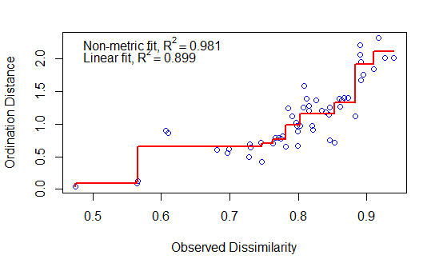

```r
set.seed(711)
NMDS1<-metaMDS(data.frame(otu_table(phylo_with_all)),trace=FALSE,try=1000,trymax=1000)
stressplot(NMDS1)
```

```r
# EXTRACT DATA FROM NMDS ANAYSIS FOR VIZ IN GGPLOTT

#these are taxa coordinates in nmds space
species_scores<-as.data.frame(NMDS1$species) %>% rownames_to_column("species")
names(species_scores)[c(2, 3)] <- c("x", "y")
species_scores$z <- NA

#these are sample coordinates in nmds space
sample_scores<-as.data.frame(NMDS1$points) %>% rownames_to_column("sample_no")
names(sample_scores)[c(2, 3)] <- c("x", "y")
sample_scores$z <- NA

# merge coordinates with the rest of taxa data
#
tax_table_df=as.data.frame(phylo_with_all@tax_table@.Data) %>% rownames_to_column("species")

species_nmds_data<-left_join(species_scores,tax_table_df, by="species")
#merge sample scores and envdata by Z_ID to get env data to symbolize points
sample_nmds_data<-metadata_env %>% left_join(sample_scores, by=c("well_no"="sample_no"))
```

## NMDS by Land cover & Geology

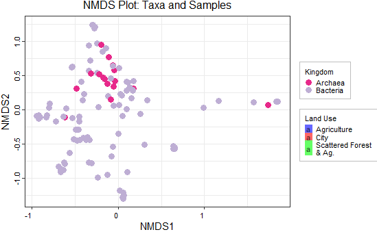

```r
NMDS_landcover_plot<-ggplot(data=species_nmds_data,aes(x=x,y=y))+
  geom_point(aes(color=Kingdom),size=3)+
  scale_color_manual(values=c("#E7298A","#BEAED4"))+
  labs(x="NMDS1",y="NMDS2")+
  geom_label_repel(data=sample_nmds_data,aes(x=x,y=y,label=well_no,fill=land_use.y),
                   alpha=0.6,size=3, fontface = 'bold',color='black',
                   point.padding = unit(0,"lines"),box.padding=unit(0,"lines"))+
  scale_fill_manual(name="Land Use",values=c("blue","red","green"),
                    labels=c("Agriculture","City","Scattered Forest\n& Ag."))+
  theme_bw()+
  theme(axis.text.x = element_text(angle = 0, hjust = 1,size=8, colour = "black"),
        axis.text.y = element_text(angle = 90, hjust = 0.5,size=8,colour="black"),
        legend.text=element_text(size=8),
        legend.title = element_text(size=8),
        legend.key.size = unit(0.3, "cm"),
        legend.background = element_rect(colour = "grey", fill=alpha("white",0.6)),
        plot.margin=margin(0,0,0,0,"cm"),
        plot.title = element_text(size=12,hjust=0.5))+
  ggtitle("NMDS Plot: Taxa and Samples")



#### Plot by geological classification 1
NMDS_geo_class1<-ggplot(data=species_nmds_data,aes(x=x,y=y))+geom_point(aes(color=Kingdom),size=3)+scale_color_manual(values=c("#E7298A","#BEAED4"))+
  labs(x="NMDS1",y="NMDS2")+
  geom_label_repel(data=sample_nmds_data,aes(x=x,y=y,label=well_no,fill=geo_class1),
                   alpha=0.6,size=3, fontface = 'bold',color='black', point.padding = unit(0,"lines"),box.padding=unit(0,"lines"))+
  scale_fill_manual(name="Land Use",values=c("blue","red","green"),labels=c("Crystalline","Sedimentary"))+
  theme_bw()+
  theme(axis.text.x = element_text(angle = 0, hjust = 1,size=8, colour = "black"),
        axis.text.y = element_text(angle = 90, hjust = 0.5,size=8,colour="black"),
        legend.text=element_text(size=8),
        legend.title = element_text(size=8),
        legend.key.size = unit(0.3, "cm"),
        legend.background = element_rect(colour = "grey", fill=alpha("white",0.6)),
        plot.margin=margin(0,0,0,0,"cm"),
        plot.title = element_text(size=12,hjust=0.5))+
  ggtitle("NMDS Plot: Taxa and Samples")


# plot by geologic  classification 2
NMDS_geo_class2<-ggplot(data=species_nmds_data,aes(x=x,y=y))+geom_point(aes(color=Kingdom),size=3)+scale_color_manual(values=c("#E7298A","#BEAED4"))+
labs(x="NMDS1",y="NMDS2")+
  geom_label_repel(data=sample_nmds_data,aes(x=x,y=y,label=well_no,fill=geo_class2),alpha=0.6,size=3, fontface = 'bold',color='black', point.padding = unit(0,"lines"),box.padding=unit(0,"lines"))+scale_fill_manual(name="Bedrock Geology",values=c("blue","red","green"),labels=c("Metamorphic","Igneous","Sedimentary"))+theme_bw()+
  theme(axis.text.x = element_text(angle = 0, hjust = 1,size=8, colour = "black"),
        axis.text.y = element_text(angle = 90, hjust = 0.5,size=8,colour="black"),
        legend.text=element_text(size=8),
        legend.title = element_text(size=8),
        legend.key.size = unit(0.3, "cm"),
        legend.background = element_rect(colour = "grey", fill=alpha("white",0.6)),
        plot.margin=margin(0,0,0,0,"cm"),
        plot.title = element_text(size=12,hjust=0.5))+
  ggtitle("NMDS Plot: Taxa and Samples")


NMDS_landcover_plot
```

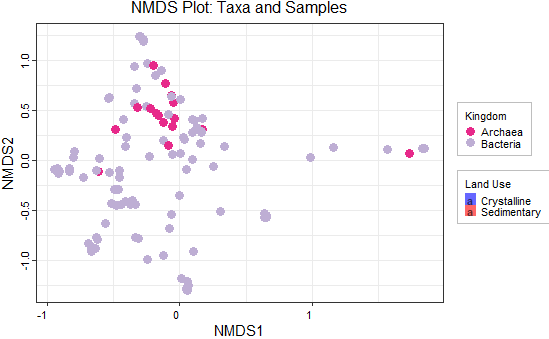

```r
NMDS_geo_class1
```

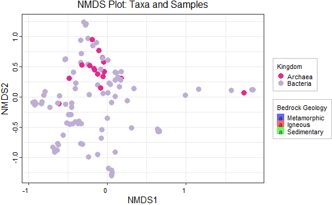

```r
NMDS_geo_class2
```

# Vector Fitting

```r
envfit_1
```

```
***VECTORS

                    NMDS1    NMDS2     r2   Pr(>r)
DEM_interp       -0.90708 -0.42096 0.2030 0.408591
elev_m           -0.96543 -0.26066 0.2960 0.237762
dist_coast       -0.95871 -0.28438 0.4332 0.116883
dist_river        0.93752  0.34793 0.1776 0.469530
temp_c            0.08541 -0.99635 0.0577 0.766234
pH_f              0.78894 -0.61447 0.1961 0.417582
cond_l            0.98323  0.18235 0.1071 0.631369
pH_l              0.28634 -0.95813 0.4509 0.096903 .
cond_f            0.99760 -0.06921 0.2273 0.340659
SWL              -0.99480 -0.10185 0.2114 0.383616
TD               -0.92862 -0.37103 0.5554 0.039960 *
WLC              -0.81143 -0.58444 0.6764 0.010989 *
Pop_1km           0.94600 -0.32416 0.5416 0.050949 .
chloride_rain     0.91378  0.40620 0.2076 0.402597
sodium_rain       0.90358  0.42842 0.1917 0.443556
Chirps_5m_precip  0.99323  0.11619 0.0505 0.810190
NDVI_1_yr        -0.99988  0.01571 0.6008 0.019980 *
Ca                0.99782 -0.06596 0.1270 0.581419
Mg                0.60826 -0.79374 0.0478 0.824176
Na                0.98030  0.19751 0.1360 0.543457
K                 0.92359 -0.38338 0.1427 0.531469
HCO3              0.48175 -0.87631 0.3333 0.194805
SO4               0.46156 -0.88711 0.0834 0.715285
Cl                0.88192  0.47141 0.4465 0.110889
NO3               0.47646  0.87920 0.5271 0.042957 *
SiO2             -0.23784 -0.97130 0.5323 0.043956 *
Al               -0.05084  0.99871 0.2062 0.388611
V                 0.96112 -0.27614 0.2923 0.252747
Cr                0.65465  0.75594 0.0276 0.890110
Mn               -0.90420 -0.42712 0.2815 0.272727
Fe               -0.79977 -0.60031 0.1371 0.560440
Co                0.49400  0.86946 0.0145 0.946054
Ni                0.11180  0.99373 0.0119 0.956044
Cu                0.15336  0.98817 0.0021 0.994006
Zn                0.16915 -0.98559 0.4542 0.085914 .
Sr                0.56337 -0.82621 0.1911 0.415584
Mo                0.82631  0.56322 0.0653 0.755245
Cd                0.49679  0.86787 0.3991 0.129870
Sb                0.84666  0.53214 0.2740 0.286713
Ba               -0.88083 -0.47344 0.3819 0.144855
Pb               -0.97274  0.23190 0.2833 0.287712
U                 0.90984 -0.41495 0.7455 0.008991 **
As                0.90934 -0.41606 0.0186 0.940060
Se                0.99808 -0.06188 0.1906 0.411588
---
Signif. codes:  0 ‘***’ 0.001 ‘**’ 0.01 ‘*’ 0.05 ‘.’ 0.1 ‘ ’ 1
Permutation: free
Number of permutations: 1000
```

# Spline fitting

Physiochemical parameters from the secondary matrix were also plotted as smoothed surfaces across the NMDS ordination space using thin-plate splines in a general additive model (GAM) framework using the ordisurf function (Vegan) (Oksanen et al., 2013).

## Total Depth Spline Fitting in NMDS space

I will just show one example where we spline Total Depth (TD)

### Basic Visualization

This is the basic visualization the ordisurf function calls. It’s intersting, but if we can manipulate the data with ggplot we can make it more beautifuland compelling.

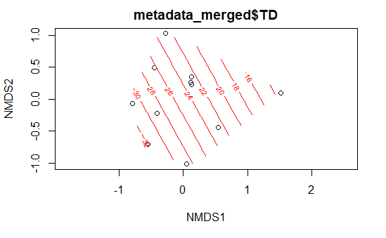

```r
td_oridsurf<-ordisurf(NMDS1,metadata_merged$TD,plot=TRUE)
```

[output not shown]